## Eating Habits and Satiety Observation

This section presents a summary of my eating habits,  
including the type of food I consumed, portion sizes,  
and how these influenced my fullness and time until I felt hungry again.

### Dynamic Comments

I recorded a total number of 29 responses.  
Overall, my average fullness after eating was 2.4827586 out of 5.

On average, it took 2.9 hour(s) (173.7931034 minutes) before I felt hungry again after eating.  
The smallest observed interval between meals was 1 hour(s) (60 minutes),  
while the longest interval was 6.5 hour(s) (390 minutes).

### Food Type Distribution

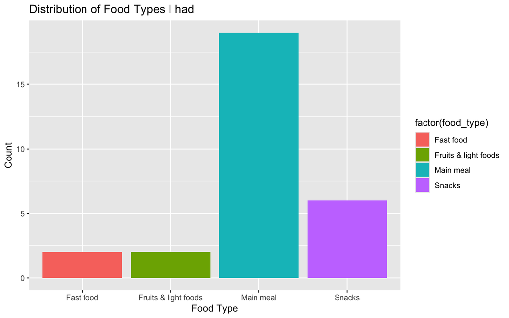

Most meals were main meals followed by snacks with limited fruit intakes,  
showing my daily eating habits pattern and suggesting that I could increase fruit consumption for better nutrition.

### Portion Size Distribution

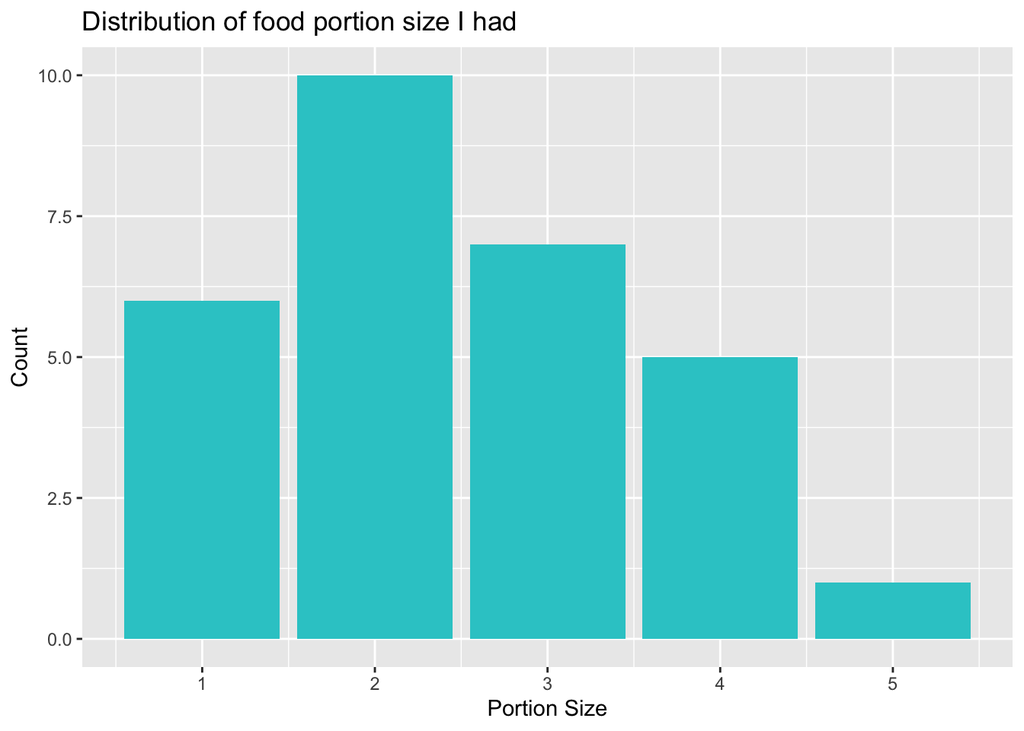

The data in this section indicates that my portion sizes are rarely very large (5),  
but there are many occasions when they are quite small (1 and 2).

On average, the portion size is about 2.4827586, which is moderate.  
This suggests that my eating habits could be improved, for example by increasing the frequency of portion sizes 3 and 4 to promote healthier eating.

### Activity porpotion across different use of time to feel hungry again

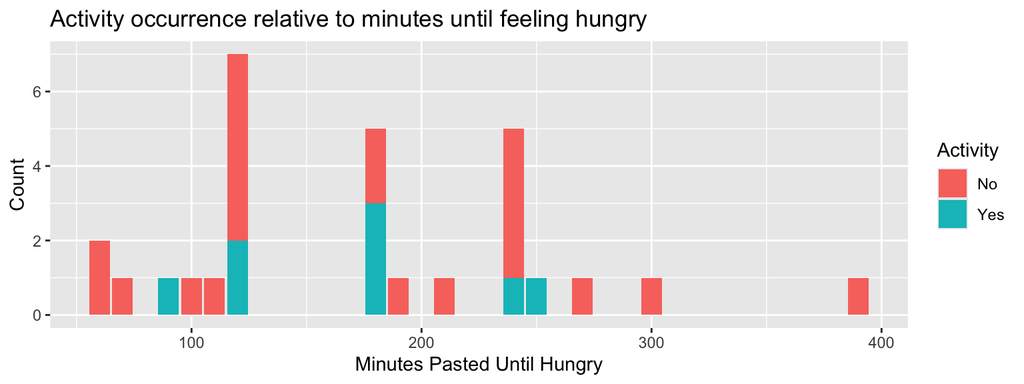

When I felt hungry, most of the time there was no activity between my previous meal and the moment I became hungry.

### Fullness level across different period of time until hungry

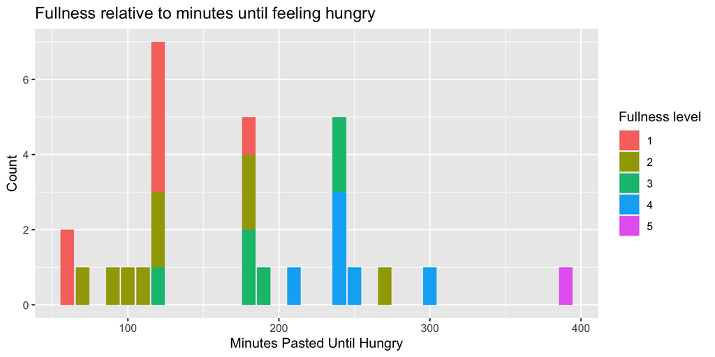

In cases where my fullness level was low, the data tends to cluster around shorter intervals, meaning I generally felt hungry again sooner after eating.

This pattern is fairly reasonable as lower fullness levels are associated with shorter times until hunger, while higher fullness levels tend to correspond to longer intervals.  
This insight suggests I could adjust portion sizes to maintain fullness longer or match my energy needs.